# Третий этап внешнего курса

Основы информационной безопасности

Казазаев Д. М.

Российский университет дружбы народов, Москва, Россия

# Информация

## Докладчик

- Казазаев Даниил Михайлович
- Студент бакалавриата
- Российский университет дружбы народов
- [1132231427@rudn.ru]
- https://github.com/KazazaevDaniil/study_2024-2025_infosec-intro

# Вводная часть

## Материалы и методы

1. Введине в криптографию
2. Цифровая подпись
3. Электронные платежи
4. Блокчейн

# Выполнение третьего этапа внешнего курса.

# Введине в криптографиюВведине в криптографию

## Введине в криптографиюВведине в криптографию

В ассиметричных криптографических примитивах обестороны имеют пару ключей. (рис. 1)

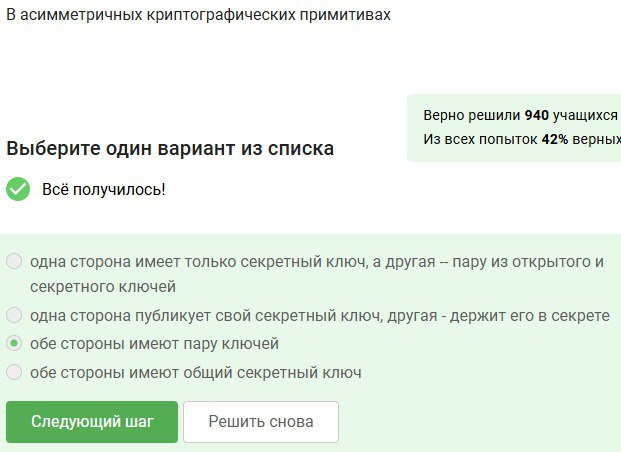

Первый вопрос

## Введине в криптографиюВведине в криптографию

Хещ-функция стойкая к колизиям, дает определенное кол-во бит вне зависимости от объема входных данных и эффективно вычисляется. (рис. 2)

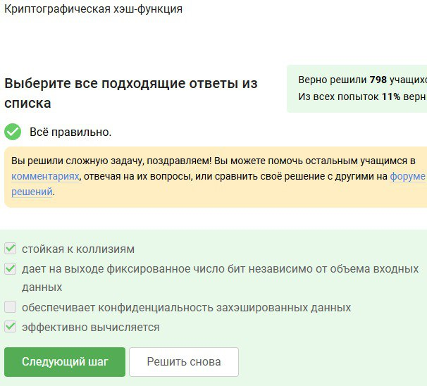

Второй вопрос

## Введине в криптографиюВведине в криптографию

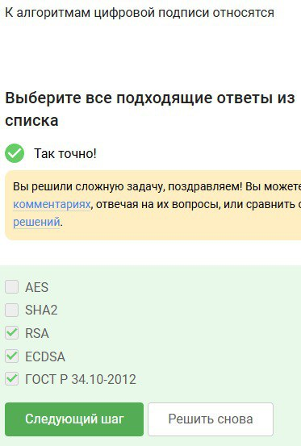

Третий вопрос

## Введине в криптографиюВведине в криптографию

Код аунтификации сообщения отеосится к симмитричным примитивам. (рис. 4)

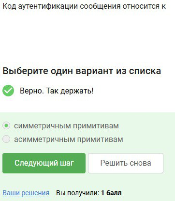

Четвертый вопрос

## Введине в криптографиюВведине в криптографию

Обмен ключами Диффи-Хэллмана - ассиметрический примитив генерации обзего секретного ключа. (рис. 5)

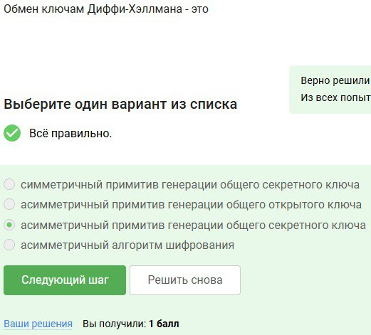

Пятый вопрос

# Цифровая подпись

## Цифровая подпись

Протоколы цифровой подписи с публичным ключом.(рис. 6)

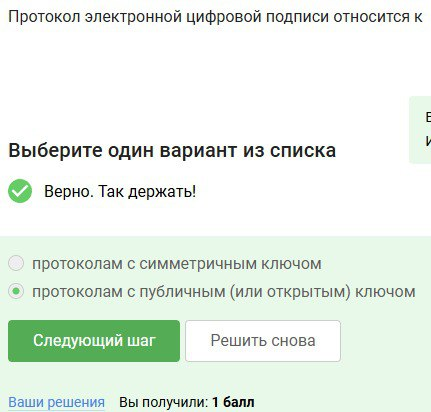

Первый вопрос

## Цифровая подпись

Алгоритм верификации требует на вход: подпись, открытый ключ, сообщение.(рис. 7)

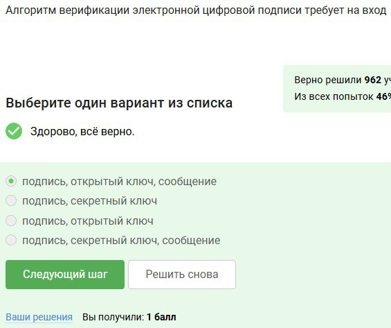

Второй вопрос

## Цифровая подпись

Электронная подпись не обеспечивает конфиденциальность.(рис. 8)

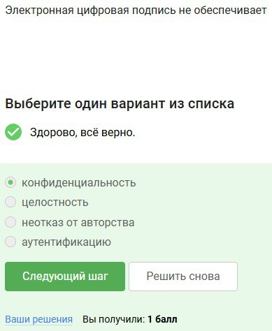

Третий вопрос

## Цифровая подпись

Для отправки налоговой отчетности необходим сертификат с усилненной квалификацией.(рис. 9)

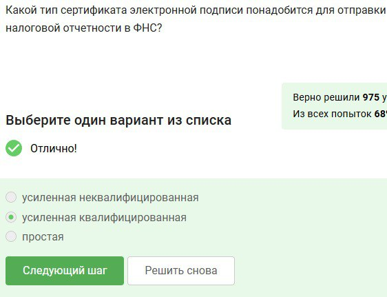

Четвертый вопрос

## Цифровая подпись

Квалифицированный сертификат можно получить в удостоверяющем центре.(рис. 10)

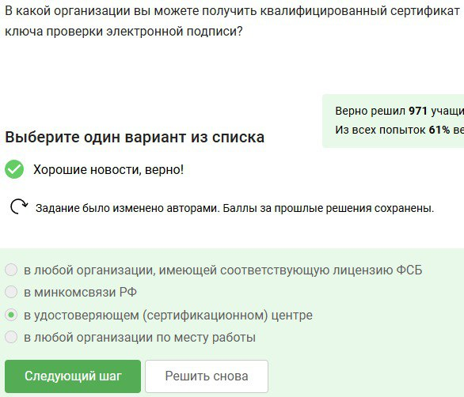

Пятый вопрос

# Электронные платежи

## Электронные платежи

МИР, MasterCard - платежные системы. (рис. 11)

[figure not shown]

Первый вопрос

## Электронные платежи

Отмеченные варианты ответов являются примером многофакторной аутентификации. (рис. 12)

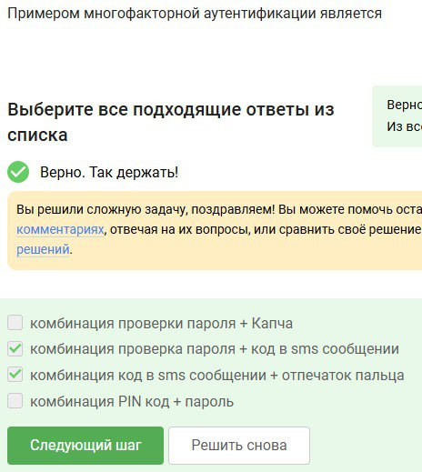

Второй вопрос

## Электронные платежи

Сегодня при онлайн платежах используется многофакторная аутентификация покупателя перед банком-эмитентом. (рис. 13)

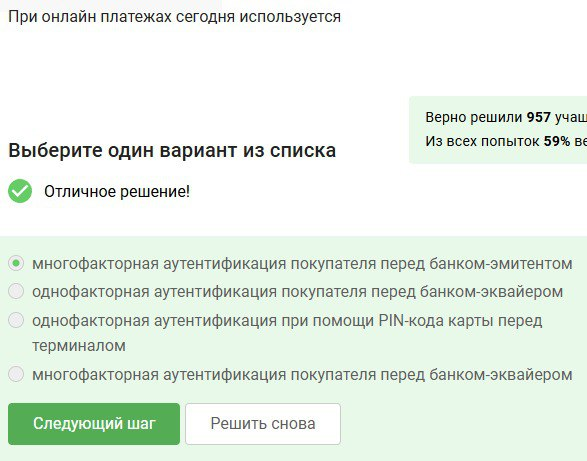

Третий вопрос

# Блокчейн

## Блокчейн

В доказательстве работы криптографической хеш-функции используется сложность нахождения прообраза. (рис. 14)

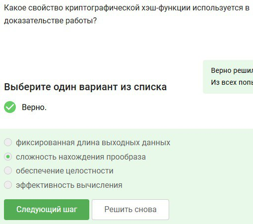

Первый вопрос

# Блокчейн

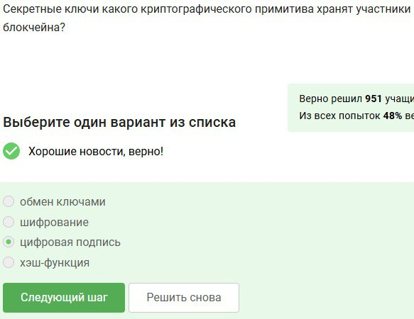

Второй вопрос

# Блокчейн

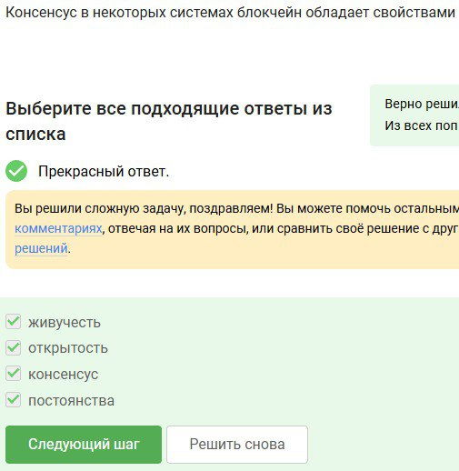

Третий вопрос

# Вывод

Выполнен третий этап внешнего курса